# Deep Learning h20

```r
#install.packages("h2o")
## Load all packages first
suppressMessages(library(h2o))
suppressMessages(library(caret))
suppressMessages(library(mlbench))
suppressMessages(library(ggplot2))
suppressMessages(library(mmand))
suppressMessages(library(PET))
```

```r
FILE.TRAIN <- "../mnist_data/mnist_train.csv"
FILE.TEST <- "../mnist_data/mnist_test.csv"
train.raw <- read.table(FILE.TRAIN, header = T, dec = ".", sep =",")
```

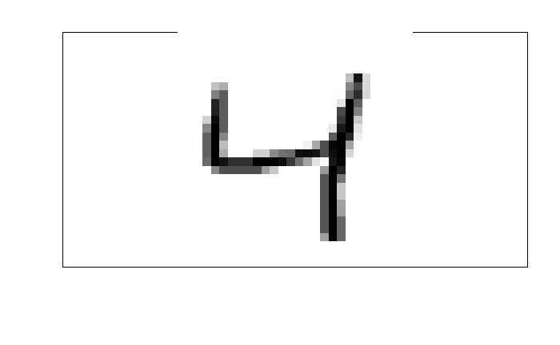

```r
rotate <- function(m) { t(apply(m, 1, rev)) }
rotate2 <- function(m) { t(apply(m, 2, rev)) }
t1 <- scaleImage( rotate(matrix(unlist(train[1,-1]), nrow = 28)) )
image(t1, col = gray((128-(0:128))/128), xaxt='n', yaxt='n', asp=1)
```

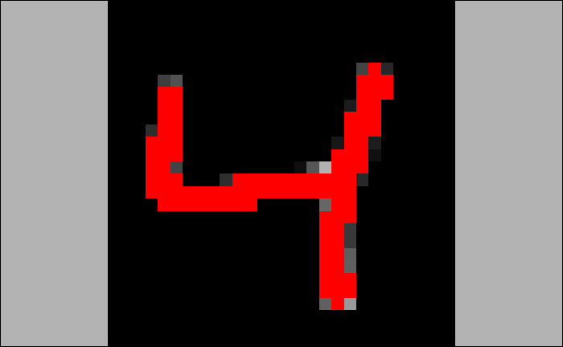

```r
k <- shapeKernel(c(3,3), type="box")
t2 <- scaleImage( rotate(rotate2(matrix(unlist(train[1,-1]), ncol = 28))) )
display(t2)
display(skeletonise(medianFilter(t2, k), k, method="lantuejoul"), col="red", add=TRUE)
```

```r
#library(DEEPR)
## start a local h2o cluster
localH2O = h2o.init(max_mem_size = '6g', # use 6GB of RAM of *GB available
                    nthreads = 6) #-1) # use all CPUs (8 on my personal computer :3)
```

```
H2O is not running yet, starting it now...

Note:  In case of errors look at the following log files:
    C:\Users\light\AppData\Local\Temp\Rtmp6PVAHU/h2o_light_started_from_r.out
    C:\Users\light\AppData\Local\Temp\Rtmp6PVAHU/h2o_light_started_from_r.err

java version "1.8.0_121"
Java(TM) SE Runtime Environment (build 1.8.0_121-b13)
Java HotSpot(TM) 64-Bit Server VM (build 25.121-b13, mixed mode)

Starting H2O JVM and connecting: .. Connection successful!

R is connected to the H2O cluster:
    H2O cluster uptime:         5 seconds 301 milliseconds
    H2O cluster version:        3.10.4.6
    H2O cluster version age:    1 month and 19 days
    H2O cluster name:           H2O_started_from_R_light_qad947
    H2O cluster total nodes:    1
    H2O cluster total memory:   5.33 GB
    H2O cluster total cores:    8
    H2O cluster allowed cores:  6
    H2O cluster healthy:        TRUE
    H2O Connection ip:          localhost
    H2O Connection port:        54321
    H2O Connection proxy:       NA
    H2O Internal Security:      FALSE
    R Version:                  R version 3.3.2 (2016-10-31)
```

```r
## MNIST data as H2O
train[,1] = as.factor(train[,1]) # convert digit labels to factor for classification
train_h2o = as.h2o(train)
test_h2o = as.h2o(test)
```

```r
## set timer
s <- proc.time()
## train model
model =
  h2o.deeplearning(x = 2:785,  # column numbers for predictors
                   y = 1,   # column number for label
                   training_frame = train_h2o, # data in H2O format
                   activation = "RectifierWithDropout", # algorithm
                   input_dropout_ratio = 0.2, # % of inputs dropout
                   hidden_dropout_ratios = c(0.5,0.5), # % for nodes dropout
                   balance_classes = TRUE,
                   hidden = c(100, 100), # two layers of 100 nodes
                   #momentum_stable = 0.99,
                   nesterov_accelerated_gradient = T, # use it for speed,
                   ignore_const_cols = F, # Dropping constant columns
                   epochs = 15) # no. of epochs
```

```r
## print confusion matrix
#h2o.confusionMatrix(model)
#h2o.confusionMatrix(model)$Error[11]
#1 - h2o.confusionMatrix(model)$Error[11]
proc.time() - s
```

```
   user  system elapsed
   1.38    0.07   24.00
```

```r
# now make a prediction
predictionsTrain <- h2o.predict(model, train_h2o)
#predictionsTrain
predictionsTest <- h2o.predict(model, test_h2o)
#predictionsTest
yhatTrain = as.factor(as.matrix(predictionsTrain$predict))
confusionMatrix(yhatTrain, train$label)
```

```
Confusion Matrix and Statistics

          Reference
Prediction    0    2    4    6    7
         0 1179    1    0    1    0
         2    1 1146    4    3    3
         4    1    7 1184    4    4
         6    3    5    1 1144    0
         7    0   10    4    0 1269

Overall Statistics

               Accuracy : 0.9913
                 95% CI : (0.9886, 0.9935)
    No Information Rate : 0.2136
    P-Value [Acc > NIR] : < 2.2e-16

                  Kappa : 0.9891
 Mcnemar's Test P-Value : NA

Statistics by Class:

                     Class: 0 Class: 2 Class: 4 Class: 6 Class: 7
Sensitivity            0.9958   0.9803   0.9925   0.9931   0.9945
Specificity            0.9996   0.9977   0.9967   0.9981   0.9970
Pos Pred Value         0.9983   0.9905   0.9867   0.9922   0.9891
Neg Pred Value         0.9990   0.9952   0.9981   0.9983   0.9985
Prevalence             0.1982   0.1957   0.1997   0.1928   0.2136
Detection Rate         0.1974   0.1918   0.1982   0.1915   0.2124
Detection Prevalence   0.1977   0.1937   0.2009   0.1930   0.2148
Balanced Accuracy      0.9977   0.9890   0.9946   0.9956   0.9958
```

```r
yhatTest = as.factor(as.matrix(predictionsTest$predict))
confusionMatrix(yhatTest, test$label)
```

```
Confusion Matrix and Statistics

          Reference
Prediction   0   2   4   6   7
         0 185   1   0   2   1
         2   0 205   1   1   7
         4   0   4 204   0   1
         6   3   4   1 201   0
         7   1   3   0   0 197

Overall Statistics

               Accuracy : 0.9706
                 95% CI : (0.9584, 0.9801)
    No Information Rate : 0.2123
    P-Value [Acc > NIR] : < 2.2e-16

                  Kappa : 0.9633
 Mcnemar's Test P-Value : NA

Statistics by Class:

                     Class: 0 Class: 2 Class: 4 Class: 6 Class: 7
Sensitivity            0.9788   0.9447   0.9903   0.9853   0.9563
Specificity            0.9952   0.9888   0.9939   0.9902   0.9951
Pos Pred Value         0.9788   0.9579   0.9761   0.9617   0.9801
Neg Pred Value         0.9952   0.9851   0.9975   0.9963   0.9890
Prevalence             0.1849   0.2123   0.2016   0.1996   0.2016
Detection Rate         0.1810   0.2006   0.1996   0.1967   0.1928
Detection Prevalence   0.1849   0.2094   0.2045   0.2045   0.1967
Balanced Accuracy      0.9870   0.9668   0.9921   0.9878   0.9757
```

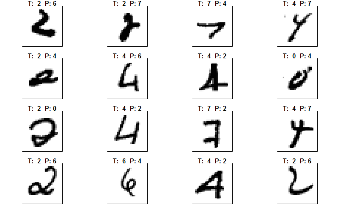

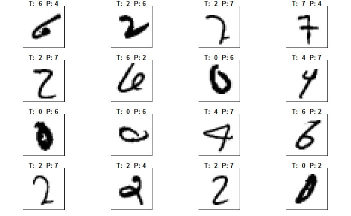

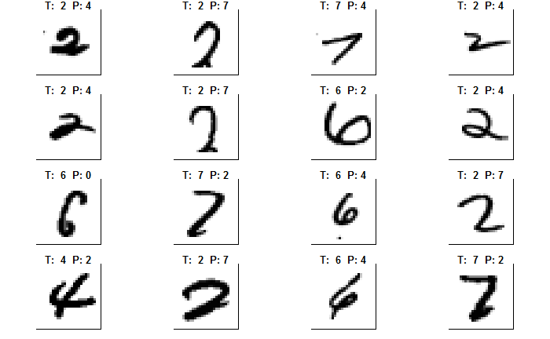

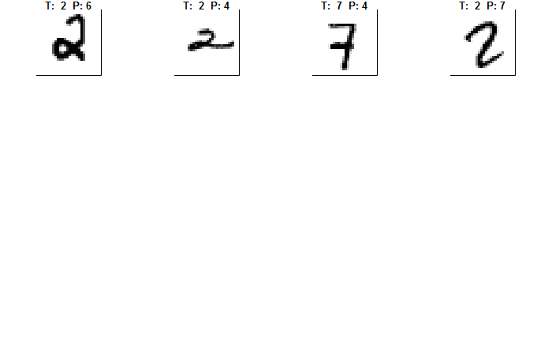

```r
a = (yhatTrain == train$label)
b = which(a=="FALSE")
c = train[b,]
d = yhatTrain[b]
par(mfrow=c(4,4),pty='s',mar=c(1,1,1,1),xaxt='n',yaxt='n')
for(i in 1:nrow(c)) {
  #z = rotate(matrix(unlist(c[i, -1]), nrow = 28))
  image(rotate(matrix(unlist(c[i, -1]), nrow = 28)), col = gray((128-(0:128))/128), xaxt='n', yaxt='n', asp=1, main = paste("T: ", c[i, 1]," P:",d[i]))
}
```

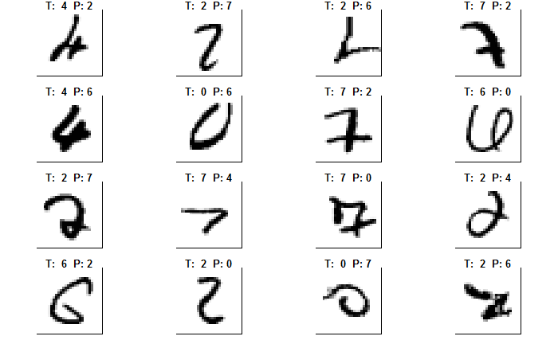

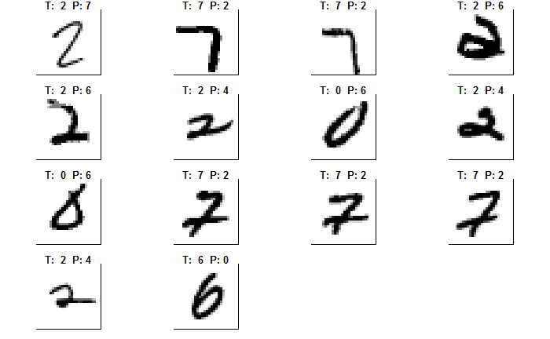

```r
a = (yhatTest == test$label)
b = which(a=="FALSE")
c = test[b,]
d = yhatTest[b]
par(mfrow=c(4,4),pty='s',mar=c(1,1,1,1),xaxt='n',yaxt='n')
for(i in 1:nrow(c)) {
  #z = rotate(matrix(unlist(c[i, -1]), nrow = 28))
  image(rotate(matrix(unlist(c[i, -1]), nrow = 28)), col = gray((128-(0:128))/128), xaxt='n', yaxt='n', asp=1, main = paste("T: ", c[i, 1]," P:",d[i]))
}
```

```r
## shut down virutal H2O cluster
h2o.shutdown(prompt = F)
```

```
[1] TRUE
```